# DeepSeek-OCR 内核级性能分析报告（V2）

## 概览

这是第 2 版（V2）报告，覆盖全部 20 个 Top 内核的完整剖析数据。V1 中有 2 个内核（kernel_0009 与 kernel_0016）缺失数据；在 V2 中已全部成功采集并完成分析。

本报告旨在基于 NVIDIA Nsight Systems（nsys）与 Nsight Compute（ncu）对 DeepSeek-OCR 模型进行内核级性能剖析，识别推理阶段的性能特征与潜在瓶颈，为面向推理的 NPU 设计提供参考。

本报告包含： - DeepSeek-OCR 推理阶段的 Top 内核 - 来自 Nsight Compute（NCU）的 20 个内核完整性能指标 - 内核执行指标的直方图 - 全量屋脊线（Roofline）分析 - 按类型（计算受限、内存受限、均衡）的内核分类 - 剖析环境与方法的实现细节

V2 的主要改进： - 100% 内核覆盖：20/20 全部成功剖析（V1 为 18/20） - kernel_0009 现被归类为“均衡”（V1 为未知） - kernel_0016 现被归类为“计算受限”（V1 为未知） - 屋脊线分析更完整，基于全量数据集

## 实验

### 环境配置

硬件： - GPU：NVIDIA GeForce RTX 5090（Blackwell 架构，sm_120） - 计算能力：12.0

软件： - CUDA：12.8 - PyTorch：2.10.0.dev20251102+cu128 - Transformers：4.46.3 - 剖析工具：NVIDIA Nsight Systems、NVIDIA Nsight Compute

模型配置： - 模型：DeepSeek-OCR - 数值精度：BF16（bfloat16） - 推理模式：自回归生成（Autoregressive） - 最大新生成 Token：64 - 温度：0.0（贪心解码） - 上下文长度模式：Auto - 不重复 N-gram 大小：20

数据集： - 数据集：OmniDocBench - 样本：20 张图像（dev-20 子集） - 预处理：Base size 1024、image size 640、启用裁剪模式

剖析配置： - 阶段 1：PyTorch Profiler（算子级分析；对阶段 2 的工作负载关闭） - 阶段 2：Nsight Systems（CUDA 时间线，使用 NVTX 对“decode”阶段门控） - Nsight Compute：Roofline、SpeedOfLight、MemoryWorkloadAnalysis、Occupancy 等章节 - 内核选择：基于 Nsys 总时间 Top 20（按解码阶段累计执行时间）

### 按总时间排序的内核（Top 15）

下表展示解码阶段（decode）累计执行时间排名前 15 的内核（由 Nsight Systems 度量）。按来源库进行归类，并给出基于功能的易读名称。

| 时间占比 | 库 | 内核名 | 说明 |
| --- | --- | --- | --- |
| 34.4% | cuBLAS | GEMV-1 (BF16, template=7) | 矩阵-向量乘，因自回归解码而占比最高 |
| 14.8% | cuBLAS | GEMV-2 (BF16, template=6) | 矩阵-向量乘，替代的分块/铺片策略 |
| 6.0% | PyTorch ATen | Direct Copy (float) | 中间张量的内存拷贝/类型转换 |
| 4.2% | PyTorch ATen | Elementwise Multiply (BF16, vec) | 向量化点乘（如注意力掩码） |
| 3.9% | PyTorch ATen | SiLU Activation (BF16, vec) | FFN 中向量化 SiLU（Swish）激活 |
| 2.9% | PyTorch ATen | Elementwise Multiply (BF16) | 非向量化点乘 |
| 2.8% | PyTorch ATen | Cat Batched Copy (vec, 128-tile) | 多头输出拼接拷贝 |
| 2.7% | PyTorch ATen | Copy/Cast (BF16, vec) | BF16 专用向量化拷贝 |
| 2.4% | FlashAttention | Flash Forward Split-KV (BF16) | 面向 IO 的分裂 K/V 融合注意力 |
| 2.0% | PyTorch ATen | Elementwise Add (BF16, vec) | 向量化加法（残差） |
| 1.8% | PyTorch ATen | Cat Batched Copy (vec, 64-tile) | 更小分块的拼接拷贝 |
| 1.8% | PyTorch ATen | Elementwise Multiply (float) | FP32 点乘 |
| 1.6% | PyTorch ATen | Mean Reduction (float) | 归一化相关归约 |
| 1.5% | PyTorch ATen | Elementwise Neg (BF16) | 取负运算 |
| 1.4% | FlashAttention | Flash Split-KV Combine | 合并分裂 K/V 的输出 |

关键观察： - GEMV 主导（49.2%）：两种 cuBLAS GEMV 变体占据近一半的执行时间，符合 batch=1 的自回归解码特征（GEMV 多于 GEMM）。 - ATen 点算子占比高（21.7%）：大量时间花在点算子内核上，存在融合空间。 - FlashAttention（3.8%）：尽管高度优化，注意力仍占据一定比例。 - 内存操作（8.7%）：直接拷贝与类型转换存在可优化的布局与数据通路空间。

### 内核分类

对 Top 20 内核全部进行了 NCU 剖析，成功率 100%（V1 为 18/20）。基于屋脊线分析进行分类：

| 分类 | 数量 | 占比 |
| --- | --- | --- |
| 内存受限 | 9 | 45.0% |
| 均衡 | 7 | 35.0% |
| 计算受限 | 4 | 20.0% |
| 未知 | 0 | 0% ✓ |

按分类的性能特征：

| 指标 | 计算受限 | 内存受限 | 均衡 | 总体均值 |
| --- | --- | --- | --- | --- |
| SM 吞吐 | 36.21% | 9.38% | 12.25% | 15.75% |
| DRAM 吞吐 | 9.89% | 34.23% | 12.62% | 21.80% |
| 内存吞吐 | 32.23% | 41.20% | 27.52% | 34.62% |
| 实际占用率 | 31.51% | 43.22% | 39.32% | 39.51% |
| L1 命中率 | - | - | - | 8.96% |
| L2 命中率 | - | - | - | 39.95% |
| 平均时长 | 137.44 μs | 9.67 μs | 39.75 μs | 45.75 μs |

要点： 1. 完整数据集（V2 改进）：20 个内核全部完成分类，消除了 V1 的不确定性。 2. SM 吞吐提升（15.75%）：较 V1（10.35%）更高，完整数据带来更准确的利用率评估。 3. 内存吞吐提升（34.62%，V1 为 27.35%）：新增内核提升了平均内存利用。 4. 占用率更高（39.51%，V1 为 30.13%）：完整数据显著提升评估值，但总体仍偏低。 5. 内存受限占比最高（45%）：近半数内核受限于内存带宽。 6. 计算受限数量增加：4 个（20%），较 V1 的 3 个（16.7%）有所增加；kernel_0016 加入该类。 7. 时长分布差异大：计算受限内核单次更慢（均值 137.44 μs）而内存受限更短（9.67 μs），表明计算型内核更复杂。 8. L2 缓存命中率下降：由 V1 的 53.48% 降至 V2 的 39.95%，暗示新增内核缓存行为更差。

新增分类（V1 → V2）： - kernel_0009：未知 → 均衡（fmha_cutlassF memory-efficient attention） - kernel_0016：未知 → 计算受限（CUTLASS GEMM 内核）

### 按单次时长排序（NCU）

下列内核在 V2 中具有最长的单次执行时长：

| 时长（μs） | 分类 | 内核 |
| --- | --- | --- |
| 404.70 | 计算受限 | CUTLASS GEMM (128×256 tile, BF16, ReLU) |
| 160.74 | 均衡 | Memory-Efficient Attention (CUTLASS BF16, 64×64) |
| 111.81 | 计算受限 | CUTLASS GEMM (256×128 tile, BF16, ReLU) |
| 94.91 | 均衡 | ATen Elementwise Add (BF16, 6144 blocks) |
| 23.42 | 计算受限 | CUTLASS GEMM (32×32 tile, BF16, WMMA) |
| 18.34 | 内存受限 | cuBLAS GEMV (BF16, template=6) |
| 18.08 | 内存受限 | ATen Direct Copy (float, 12288 blocks) |
| 10.34 | 内存受限 | FlashAttention Split-KV Forward |
| 9.82 | 计算受限 | ATen Cat Batched Copy (512-thread blocks) |
| 7.97 | 内存受限 | ATen Mean Reduction (float, 512 threads) |

### 内核执行指标的直方图

以下直方图展示了所有被剖析内核在关键性能指标上的分布，用于发现共性与离群点。

#### 计算与内存吞吐

SM 吞吐（峰值百分比）

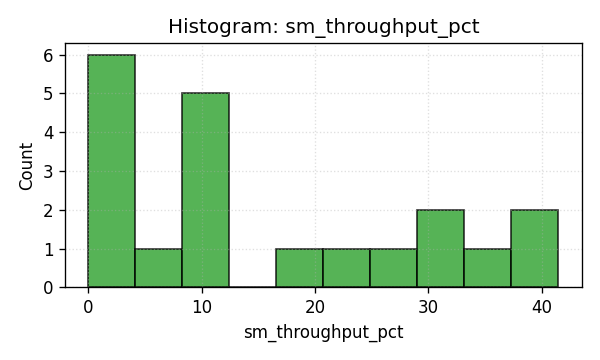

SM Throughput Distribution

大多数内核的 SM 利用率很低（<15%），验证了整体计算资源利用不足。

DRAM 吞吐（峰值百分比）

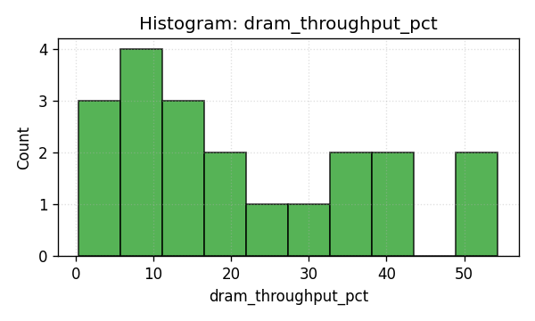

DRAM Throughput Distribution

内存吞吐（峰值百分比）

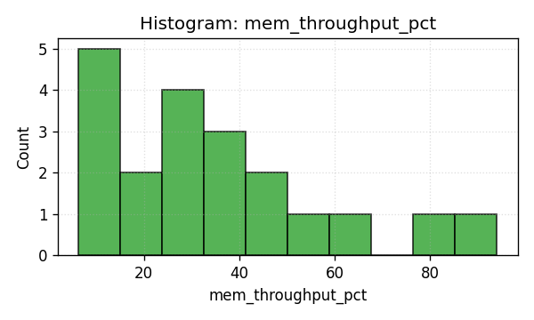

Memory Throughput Distribution

内存吞吐（GB/s）

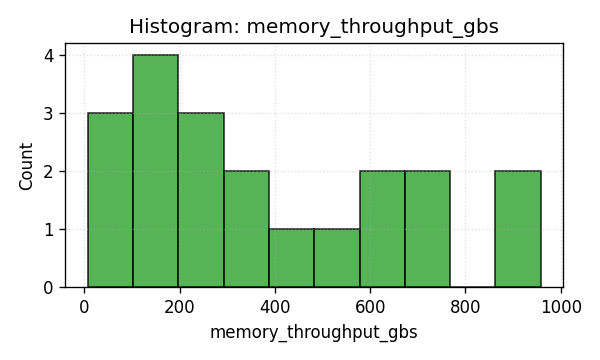

Memory Throughput Absolute

绝对带宽显示多数内核在 5-400 GB/s 范围内运行，远低于 RTX 5090 的理论峰值。

#### 缓存性能

L1 纹理缓存命中率

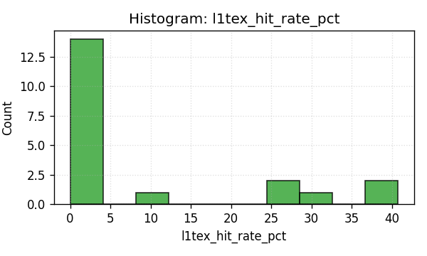

L1 Hit Rate Distribution

L1 命中率极低，多数内核仅 0-10% 命中，提示工作集超出 L1 容量或空间局部性较差。

L1 纹理缓存吞吐（峰值百分比）

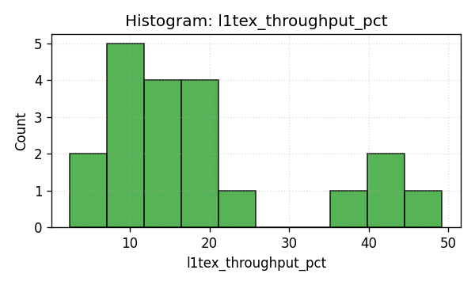

L1 Throughput Distribution

L1 吞吐分布较宽（2-50%），表明不同内核的缓存访问模式差异较大。

L2 缓存命中率

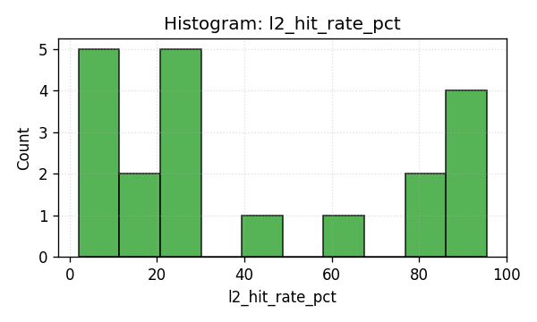

L2 Hit Rate Distribution

L2 命中率明显好于 L1，聚集在 15-90%，说明工作集有部分可在 L2 中复用。

L2 缓存吞吐（峰值百分比）

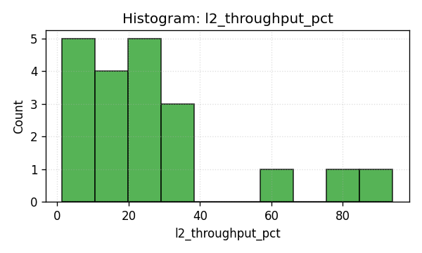

L2 Throughput Distribution

L2 吞吐多数位于 1-30%，存在 80-90% 的离群点，表征重度 L2 流量。

#### 占用率指标

实际占用率（Achieved Occupancy）

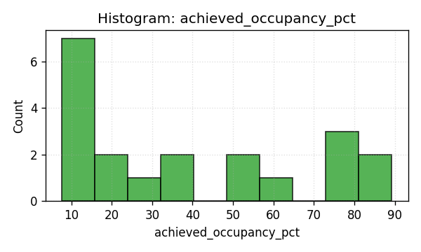

Achieved Occupancy Distribution

实际占用率分布很散，从接近 0% 到 90%，大量内核位于 7-40%，提示并行度不足。

理论占用率（Theoretical Occupancy）

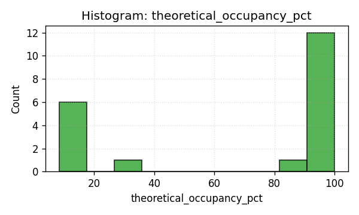

Theoretical Occupancy Distribution

理论上多数内核可达到 80-100% 占用，但实际远低，说明运行时瓶颈（内存延迟、同步）阻碍了利用率提升。

#### 内核时长与内存活动

内核时长（Duration）

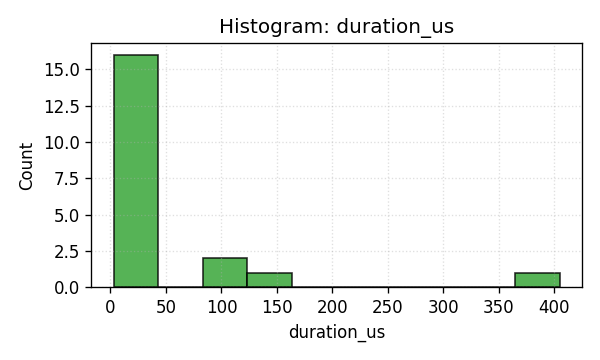

Duration Distribution

内存忙碌百分比（Memory Busy %）

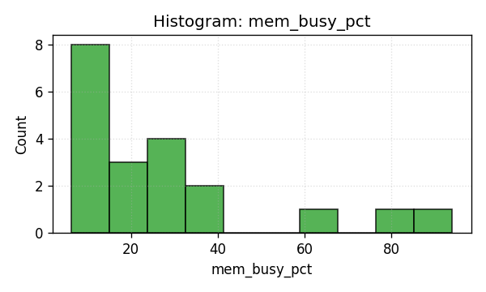

Memory Busy Distribution

内存子系统忙碌时间跨度较大，内存受限内核可让内存保持 20-90% 的忙碌度。

最大带宽利用率（Max Bandwidth %）

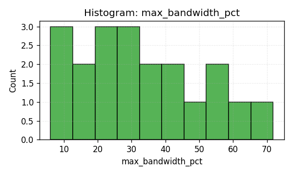

Max Bandwidth Distribution

跨全部内存类型的峰值带宽利用率大多仅 5-50% 的水平。

上述直方图揭示了被剖析内核在关键性能指标上的分布特征，便于识别共性与离群点。

### 屋脊线（Roofline）分析

屋脊线分析以“算术强度（每字节 FLOPs）- 实际性能（FLOP/s）”散点，刻画内核相对硬件上限的性能表现。

#### 归一化屋脊线

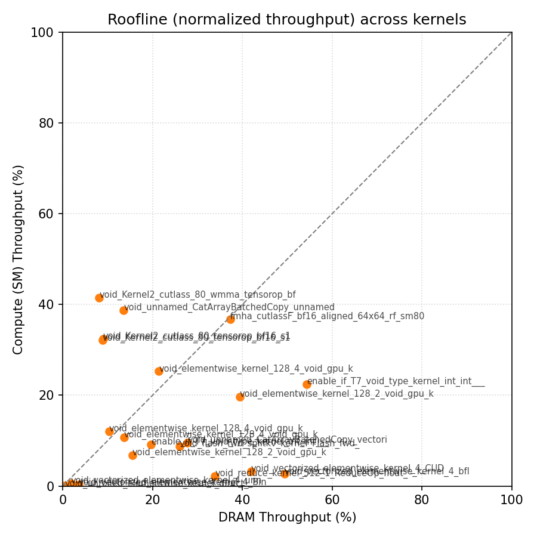

Roofline Scatter - Normalized

#### 物理屋脊线

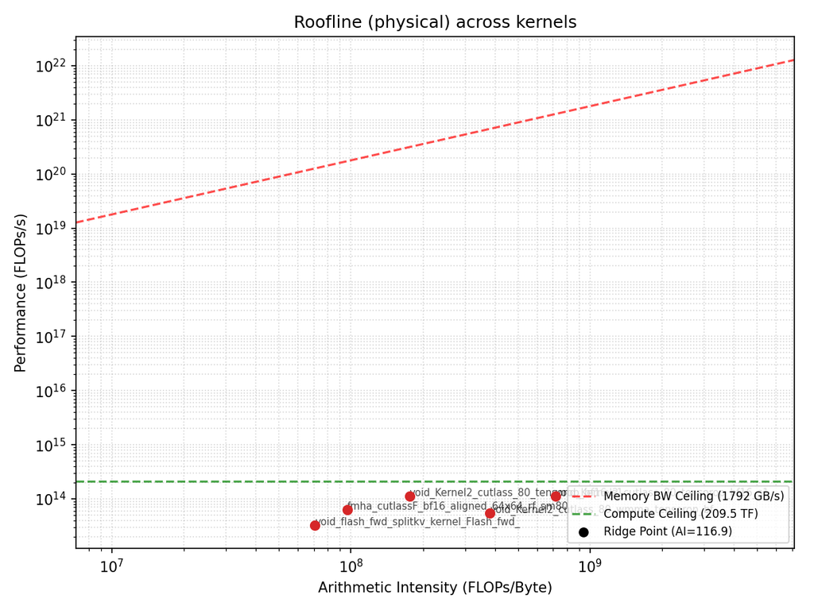

Roofline Scatter - Physical

每个内核的单独屋脊线图（归一化与物理）均可在 `ncu-v2/analysis/roofline_per_kernel/` 中查看。

总体上，多数内核远未达到内存或计算屋脊，存在显著优化空间；大多数内核实际性能低于理论上限的 50%。

## 结论

### 主要发现

1. 覆盖完整（V2 达成）：Top 20 全部完成剖析，相比 V1 的 90% 覆盖提升为 100%；此前未知的 kernel_0009 与 kernel_0016 已全部刻画。
2. GEMV 瓶颈（49.2% 时间）：自回归解码以 GEMV 为主（batch=1），天然更偏内存受限，计算利用率在现代 GPU 上不高。
3. 硬件利用率虽有提升但仍偏低：
   - SM 吞吐 15.75%（V1 为 10.35%）
   - 内存吞吐 34.62%（V1 为 27.35%）
   - 实际占用率 39.51%（V1 为 30.13%）
   - 即使提升明显，整体利用率仍较低。
4. 完整数据导致的内存层级变化：
   - L1 命中率依旧很低（8.96%，与 V1 的 8.85% 相当）
   - L2 命中率降至 39.95%（V1 为 53.48%），提示新增内核缓存局部性更差
   - 可能与 kernel_0009（记忆高效注意力）和 kernel_0016（CUTLASS GEMM）的访问模式有关
5. 内核融合机会：大量小型点算子（乘、加、激活等）共占 21.7% 时间，具备显著融合潜力，可降低访存与启动开销。
6. 混合精度开销：频繁的 BF16 ↔︎ FP32 转换（拷贝/类型转换约 6%）显示数据类型管理可进一步优化。
7. 注意力内核洞见（V2 新发现）：
   - kernel_0009（记忆高效注意力）单次 160.74 μs，归为“均衡”，同时对计算与内存利用率都不高；
   - 相比 FlashAttention（10.34 μs）慢 15.5 倍，提示替换或引入 FA 变体的潜力。
8. 计算受限内核增多：由 V1 的 3 个增至 4 个（20%），其中 kernel_0016（CUTLASS GEMM）新增；该类内核平均 137.44 μs，远高于内存受限（9.67 μs）与均衡（39.75 μs）。

### 识别出的性能瓶颈

1. 解码阶段 GEMV 效率不足：batch=1 的 GEMV 难以有效利用张量核，也难以跑满内存带宽。
2. 并行度不足：广泛的低占用率显示工作并行度不足以饱和 RTX 5090 的巨大并行资源（21,760 CUDA cores、680 Tensor Cores）。
3. 内存层级利用不足：L1/L2 命中率不高，说明
   - 工作集不适配 L1 容量；
   - 时间局部性利用不足；
   - 预取/访问模式可进一步优化。
4. 内核启动开销：大量短小内核（<5 μs）导致启动开销相对计算时间占比偏高。

### 优化建议（软件侧）

1. 持续批处理（Continuous Batching）：通过持续批处理或投机解码扩大解码期的 batch，将 GEMV 转化为更高效的 GEMM。
2. 内核融合：
   - 融合点算子（乘、加、激活）
   - 融合 LayerNorm + Linear + Activation 常见序列
   - 基于 torch.compile 或自定义 CUDA 内核优化关键路径
3. KV-Cache 优化：
   - Paged attention 优化 KV-Cache 访存
   - 采用 FlashDecoding 等面向解码期的优化技术
   - KV-Cache 量化（INT8/INT4）缓解内存带宽压力
4. 内存布局优化：
   - 尽量减少 BF16 ↔︎ FP32 转换，扩大 BF16 的覆盖面
   - 尽量原地（in-place）操作，降低拷贝
   - 优化张量布局，提升连续访问
5. 提升并行度：
   - 以合批方式提升吞吐（多请求合并）
   - 预填充（prefill）/解码（decode）解耦并在不同实例运行
   - 多查询/分组查询注意力（MQA/GQA）降低解码带宽

### 面向推理的 NPU 设计建议

基于本次剖析，针对类似 DeepSeek-OCR 的视觉-语言模型，提出如下面向推理优化的 NPU 架构建议：

#### 1. Tensor Core / CUDA Core 配比

建议： - 相比训练型 GPU 适度降低张量核密度（例如晶体管面积占比 30-40%，而非 H100 的 50%+） - 增加 CUDA cores 以更好承载点算子与内存受限工作 - 为 GELU、SiLU、LayerNorm 等常用激活/归一化提供专用单元（替代多个分散小内核） - 提供 INT4/INT8 张量核以支持极致量化推理

#### 2. 内存带宽需求

建议： - 相比训练型 GPU 可适当降低带宽配置而不显著影响此类推理工作负载 - 高端推理 NPU 的目标带宽 2-3 TB/s（H100 为 3.35 TB/s） - 将节省下的面积/功耗投入到更大的片上缓存 - 解码期更重视 HBM 延迟而非纯带宽

#### 3. L1 / L2 缓存比例与容量

建议： - 大幅提升 L2（目标 128-256 MB；A100 为 50 MB） - 缩小或可配置化 L1（与共享内存可互换） - 在 L1 与 L2 之间增设 victim cache 捕获逐出数据 - 为 KV-Cache 设立高带宽片上 SRAM（32-64 MB）以降低 DRAM 访问 - 针对 Transformer 访问模式（顺序访问 KV-Cache）优化替换策略

#### 4. 专用解码单元

发现：49.2% 时间消耗在 GEMV 上，利用率不高。

建议： - 专用 GEMV 加速（batch=1、低时延） - 面向解码配置的脉动阵列：更窄（如 128 列而非 256+）、更深，以流水线并行多个小 GEMV - 权值驻留（weight-stationary）数据流：重复解码步骤下将权值留在片上 - 小规模全连接层尝试片上 SRAM 内计算，进一步消除 DRAM 访问

#### 5. 硬件级算子融合

发现：21.7% 的时间用于可融合的小型点算子。

建议： - 可编程融合引擎，将多步运算合并，避免往返内存 - 支持常见融合模式：`linear → activation`、`add → layernorm`、`multiply → add → activation` - 提供宏指令（Macro-op ISA）描述融合序列 - 支持动态控制流，提升内核内分支效率

#### 6. 精度与数据类型支持

发现：BF16 为主，但转换带来 ~6% 开销；混合精度普遍存在。

建议： - 全链路原生 BF16 - 硬件加速 FP8（E4M3/E5M2）权值与激活，最小化开销 - 张量核支持 INT4/INT8 极致量化 - 支持每通道动态范围，便于精细量化 - 降低不同格式间的转换开销（理想为单周期）

#### 7. 并行度与占用率

建议： - 相比训练型 GPU 适当减少 SM 数量（如 60-80 vs. H100 的 132） - 单 SM 内更深的流水以挖掘指令级并行 - 更大的 warp/线程组，摊薄调度与控制开销 - 更强的延迟隐藏机制，针对解码期访问模式优化 - 硬件支持细粒度合批，聚合多条单 token 操作

#### 8. 互连与多芯扩展

建议： - 降低芯片间带宽需求（300-500 GB/s，相对 NVLink 900 GB/s），推理更少全规约通信 - 优化管线并行与张量并行，弱化数据并行依赖 - 支持非对称拓扑，将预填充与解码实例分离 - 为预填充-解码解耦架构提供快速 KV-Cache 交换

#### 9. 能效

建议： - 相比训练 GPU 追求 3-5 倍 TOPS/W 的能效，通过降低张量核密度与带宽实现 - 在内存受限阶段对闲置张量核进行积极时钟门控 - 将 DVFS 策略围绕推理时延目标（如 P99）而非吞吐进行优化 - 提供解码/预填充阶段的差异化低功耗模式

剖析产物：所有原始数据、指标、直方图、屋脊线图与分析脚本均位于 `reports/20251107-dsocr/ncu-v2/analysis/`。

## 附录：完整内核函数名

本附录给出完整（未截断）的内核函数名，便于溯源与调试。对应“按总时间排序的内核”章节中的条目。

### 内核名称映射表

下表将易读的内核名映射到分析工具输出中的完整（经名称重整）函数签名。

| 排名 | 时间占比 | 易读内核名 | 库 | 完整函数签名 |
| --- | --- | --- | --- | --- |
| 1 | 34.4% | GEMV-1 (BF16, template=7) | cuBLAS | `std::enable_if<!T7, void>::type internal::gemvx::kernel<int, int, __nv_bfloat16, __nv_bfloat16, __nv_bfloat16, float, (bool)0, (bool)1, (bool)1, (bool)0, (int)7, (bool)0, cublasGemvParamsEx<int, cubl… |
| 2 | 14.8% | GEMV-2 (BF16, template=6) | cuBLAS | `std::enable_if<!T7, void>::type internal::gemvx::kernel<int, int, __nv_bfloat16, __nv_bfloat16, __nv_bfloat16, float, (bool)0, (bool)1, (bool)1, (bool)0, (int)6, (bool)0, cublasGemvParamsEx<int, cubl… |
| 3 | 6.0% | Direct Copy (float) | PyTorch ATen | `void at::native::unrolled_elementwise_kernel<at::native::direct_copy_kernel_cuda(at::TensorIteratorBase &)::[lambda() (instance 3)]::operator ()() const::[lambda() (instance 7)]::operator ()() const:… |
| 4 | 4.2% | Elementwise Multiply (BF16, vec) | PyTorch ATen | `void at::native::vectorized_elementwise_kernel<(int)4, at::native::BinaryFunctor<c10::BFloat16, c10::BFloat16, c10::BFloat16, at::native::binary_internal::MulFunctor<float>>, std::array<char *, (unsi… |
| 5 | 3.9% | SiLU Activation (BF16, vec) | PyTorch ATen | `void at::native::vectorized_elementwise_kernel<(int)4, at::native::<unnamed>::silu_kernel(at::TensorIteratorBase &)::[lambda() (instance 1)]::operator ()() const::[lambda() (instance 6)]::operator ()… |
| 6 | 2.9% | Elementwise Multiply (BF16) | PyTorch ATen | `void at::native::elementwise_kernel<(int)128, (int)4, void at::native::gpu_kernel_impl_nocast<at::native::BinaryFunctor<c10::BFloat16, c10::BFloat16, c10::BFloat16, at::native::binary_internal::MulFu… |
| 7 | 2.8% | Cat Batched Copy (vec, 128-tile) | PyTorch ATen | `void at::native::<unnamed>::CatArrayBatchedCopy_vectorized<at::native::<unnamed>::OpaqueType<(unsigned int)2>, unsigned int, (int)3, (int)128, (int)1, (int)16, (int)8>(char *, at::native::<unnamed>::… |
| 8 | 2.7% | Copy/Cast (BF16, vec) | PyTorch ATen | `void at::native::vectorized_elementwise_kernel<(int)4, at::native::bfloat16_copy_kernel_cuda(at::TensorIteratorBase &)::[lambda(float) (instance 1)], std::array<char *, (unsigned long)2>>(int, T2, T3… |
| 9 | 2.4% | Flash Forward Split-KV (BF16) | FlashAttention | `void flash::flash_fwd_splitkv_kernel<Flash_fwd_kernel_traits<(int)128, (int)64, (int)128, (int)4, (bool)0, (bool)0, cutlass::bfloat16_t, Flash_kernel_traits<(int)128, (int)64, (int)128, (int)4, cutla… |
| 10 | 2.0% | Elementwise Add (BF16, vec) | PyTorch ATen | `void at::native::vectorized_elementwise_kernel<(int)4, at::native::CUDAFunctor_add<c10::BFloat16>, std::array<char *, (unsigned long)3>>(int, T2, T3)` |
| 11 | 1.8% | Cat Batched Copy (vec, 64-tile) | PyTorch ATen | `void at::native::<unnamed>::CatArrayBatchedCopy<at::native::<unnamed>::OpaqueType<(unsigned int)2>, unsigned int, (int)4, (int)64, (int)64>(T1 *, at::native::<unnamed>::CatArrInputTensorMetadata<T1, … |
| 12 | 1.8% | Elementwise Multiply (float) | PyTorch ATen | `void at::native::elementwise_kernel<(int)128, (int)2, void at::native::gpu_kernel_impl_nocast<at::native::BinaryFunctor<float, float, float, at::native::binary_internal::MulFunctor<float>>>(at::Tenso… |
| 13 | 1.6% | Mean Reduction (float) | PyTorch ATen | `void at::native::reduce_kernel<(int)512, (int)1, at::native::ReduceOp<float, at::native::MeanOps<float, float, float, float>, unsigned int, float, (int)4, (int)4>>(T3)` |
| 14 | 1.5% | Elementwise Neg (BF16) | PyTorch ATen | `void at::native::elementwise_kernel<(int)128, (int)4, void at::native::gpu_kernel_impl_nocast<at::native::neg_kernel_cuda(at::TensorIteratorBase &)::[lambda() (instance 2)]::operator ()() const::[lam… |
| 15 | 1.4% | Flash Split-KV Combine | FlashAttention | `void flash::flash_fwd_splitkv_combine_kernel<Flash_fwd_kernel_traits<(int)128, (int)64, (int)128, (int)4, (bool)0, (bool)0, cutlass::bfloat16_t, Flash_kernel_traits<(int)128, (int)64, (int)128, (int)… |

### 函数名解读说明

模板参数： - 尖括号 `< >` 中的值为编译期配置 - 数据类型：`__nv_bfloat16`、`float`、`c10::BFloat16`、`cutlass::bfloat16_t` - 分块/铺片尺寸：如 `(int)128, (int)64, (int)128, (int)4` 对应 block/warp/thread 等配置 - 布尔开关：`(bool)0`（false）、`(bool)1`（true）控制内核变体

名称重整（Mangled）： - `T1`、`T2`、`T3` 等为 C++ 模板参数占位符 - cuBLAS 中的 `T13` 表示参数包展开

Lambda 表达式： - `[lambda() (instance N)]` 为 PyTorch 函数式风格生成的匿名函数 - 通过实例编号区分相似签名的多个 lambda

命名空间前缀： - `at::native::` - PyTorch ATen（A Tensor Library）原生 CUDA 内核 - `internal::gemvx::` - cuBLAS 内部 GEMV 实现 - `flash::` - FlashAttention 内核

实践用途： 1. 在 Nsight Compute `.ncu-rep` 或 CSV 中进行精确字符串匹配 2. 复制完整签名以过滤分析输出 3. 追踪至 PyTorch/cuBLAS/CUTLASS 的具体模板实例 4. 与 `ncu-v2/analysis/roofline_per_kernel/` 中的每内核屋脊线图交叉引用 5. 解析函数签名以抽取配置参数用于自动化分析

相似内核的关键差异： - GEMV-1 vs GEMV-2：模板参数 `(int)7` vs `(int)6`，影响内部铺片策略 - Cat Batched Copy 变体：`(int)3, (int)128` vs `(int)4, (int)64`，指定拷贝维度与分块大小 - 向量化 vs 非向量化点算子：`vectorized_elementwise_kernel` 使用向量装载/存储（`(int)4` 表示 4 元向量）